# Module 1: The Exposome — Motivation, Biology, and NHANES

## Welcome to the Course

**Conducting Exposome-Wide Association Studies (ExWAS)**

- 7-module online course
- Learn the statistics and biology behind ExWAS
- Hands-on R programming with real NHANES data
- Culminates in running and interpreting your own ExWAS

## Course Overview

| Module | Topic |
| --- | --- |
| 1 | The Exposome: Motivation, Biology, and NHANES |
| 2 | R and Tidyverse Foundations |
| 3 | Statistical Foundations for ExWAS |
| 4 | The nhanespewas Package |
| 5 | Conducting an ExWAS |
| 6 | Interpreting ExWAS Results |
| 7 | Advanced Topics |

## What is the Exposome?

> “The exposome encompasses the totality of human environmental exposures from conception onwards, complementing the genome.”

> — Christopher Wild, 2005
- The **genome** is the complete set of DNA
- The **exposome** is the complete set of environmental exposures
- Together, they shape health and disease

## The E-G-P-D Framework

Our conceptual model links:

- **E**nvironment (exposures): chemicals, nutrients, pollutants, lifestyle
- **G**enome: inherited genetic variation
- **P**henotype: measurable traits (BMI, glucose, blood pressure)
- **D**isease: clinical outcomes (T2D, cardiovascular disease)

\[E + G \rightarrow P \rightarrow D\]

Understanding the exposome means understanding **E** in this framework.

## Why Study the Exposome?

**The rise of chronic disease:**

- Type 2 diabetes prevalence has increased dramatically over the past 40 years
- Obesity rates have tripled since the 1970s
- Genetics alone cannot explain these rapid changes
- Environmental factors — diet, chemicals, lifestyle — are key drivers

CDC Diabetes Atlas: https://www.cdc.gov/diabetes/php/data-research/index.html

## Genetic vs. Environmental Contributions

- Genome-Wide Association Studies (GWAS) have identified hundreds of loci for complex traits
- Yet GWAS variants typically explain **<20%** of trait heritability
- The “missing heritability” problem suggests environmental factors play a large role
- **ExWAS** is the environmental analogue of GWAS

## What is an ExWAS?

**Exposome-Wide Association Study (ExWAS):**

- Systematically test associations between **many** environmental exposures and a health outcome
- Analogous to GWAS: instead of scanning SNPs, scan exposures
- Data-driven, hypothesis-generating approach

First described in: **Patel et al. 2010, PLoS ONE**

## ExWAS: The Concept

1. Measure a large panel of environmental exposures (E₁, E₂, …, Eₘ)
2. Measure a phenotype or disease outcome (P or D)
3. Test each exposure-phenotype association individually
4. Correct for multiple testing
5. Replicate findings in independent data

## The National Health and Nutrition Examination Survey (NHANES)

- Conducted by the US CDC / National Center for Health Statistics (NCHS)
- Representative sample of the non-institutionalized US population
- Continuous since 1999, released in 2-year cycles
- Combines **interviews**, **physical examinations**, and **laboratory tests**

https://www.cdc.gov/nchs/nhanes/index.htm

## Why NHANES for ExWAS?

- Hundreds of environmental biomarkers measured in blood and urine
- Linked to health phenotypes (BMI, glucose, lipids, blood pressure)
- Demographic and socioeconomic data available
- Survey weights enable nationally representative estimates
- Publicly available and well-documented

## NHANES Sampling Design

NHANES uses a **complex, multi-stage probability sampling** design:

1. **Primary Sampling Units (PSUs)**: counties or groups of counties
2. **Strata**: geographic/demographic divisions within PSUs
3. **Households**: selected within strata
4. **Individuals**: selected within households

This design requires special statistical methods (Module 3).

## NHANES Survey Cycles

| Cycle | Years | Key Variables |
| --- | --- | --- |
| 1 | 1999-2000 | Core demographics, lab biomarkers |
| 2 | 2001-2002 | Expanded environmental panel |
| 3 | 2003-2004 | Continued monitoring |
| 4 | 2005-2006 | Additional pollutants |
| … | … | Ongoing |

Our training data uses cycles 1-2; testing data uses cycles 3-4.

## Types of Exposures in NHANES

**Biomarkers of environmental exposure:**

- **Metals**: lead (Pb), cadmium (Cd), mercury (Hg)
- **Persistent organic pollutants**: PCBs, dioxins, pesticides
- **Volatile organic compounds**: benzene metabolites
- **Nutrients**: vitamins, minerals, fatty acids
- **Lifestyle**: cotinine (smoking), caffeine

Measured in **blood** and **urine** samples.

## Let’s Load Our Data

```r
load('../data/nh.Rdata')
```

This `.Rdata` file contains:

- `NHData.train`: training dataset (NHANES 1999-2002)
- `NHData.test`: testing dataset (NHANES 2003-2006)
- `ExposureList`: array of exposure variable names
- `ExposureDescription`: dictionary of exposure variables
- `demographicVariables`: dictionary of demographic variables

## Exploring the Training Data

```r
dim(NHData.train)
```

```
## [1] 21004   193
```

```r
ncol(NHData.train)
```

```
## [1] 193
```

We have **21004** individuals and **193** variables in the training set.

## How Many Exposures?

```r
length(ExposureList)
```

```
## [1] 160
```

We have **160** environmental exposures to test.

## Exposure Descriptions

```r
head(ExposureDescription, 10) %>%
  kable() %>%
  kable_styling(font_size = 9)
```

|  | tab_name | tab_desc | series | module | var | var_desc | tab_desc_ewas | analyzable | var_desc_ewas | binary_ref_group | var_desc_ewas_sub | comment_var | version_date | is_comment | is_weight | is_questionnaire | is_ecological | is_binary | is_ordinal | categorical_ref_group | categorical_levels |
| --- | --- | --- | --- | --- | --- | --- | --- | --- | --- | --- | --- | --- | --- | --- | --- | --- | --- | --- | --- | --- | --- |
| 52 | l06bmt_c | Blood Lead, Cadmium, Mercury | 2003-2004 | laboratory | LBXBCD | Cadmium (ug/L) | heavy metals | 1 | heavy metals | NA | NA | NA | 2009-11-13 | 0 | 0 | 0 | 0 | 0 | NA | NA | NA |
| 54 | l06bmt_c | Blood Lead, Cadmium, Mercury | 2003-2004 | laboratory | LBXBPB | Lead (ug/dL) | heavy metals | 1 | heavy metals | NA | NA | NA | 2009-11-13 | 0 | 0 | 0 | 0 | 0 | NA | NA | NA |
| 56 | l06bmt_c | Blood Lead, Cadmium, Mercury | 2003-2004 | laboratory | LBXTHG | Mercury, total (ug/L) | heavy metals | 1 | heavy metals | NA | NA | NA | 2009-11-13 | 0 | 0 | 0 | 0 | 0 | NA | NA | NA |
| 58 | l06bmt_c | Blood Lead, Cadmium, Mercury | 2003-2004 | laboratory | LBXIHG | Mercury, inorganic (ug/L) | heavy metals | 1 | heavy metals | NA | NA | NA | 2009-11-13 | 0 | 0 | 0 | 0 | 0 | NA | NA | NA |
| 60 | l06cot_c | Cotinine | 2003-2004 | laboratory | LBXCOT | Cotinine (ng/mL) | biochemistry | 1 | cotinine | NA | NA | NA | 2009-11-13 | 0 | 0 | 0 | 0 | 0 | NA | NA | NA |
| 61 | l06hm_c | Heavy Metals | 2003-2004 | laboratory | URXUBA | Barium, urine (ng/mL) | heavy metals | 1 | heavy metals | NA | NA | URDUBALC | 2009-11-13 | 0 | 0 | 0 | 0 | 0 | NA | NA | NA |
| 62 | l06hm_c | Heavy Metals | 2003-2004 | laboratory | URXUBE | Beryllium, urine (ng/mL) | heavy metals | 1 | heavy metals | NA | NA | URDUBELC | 2009-11-13 | 0 | 0 | 0 | 0 | 0 | NA | NA | NA |
| 63 | l06hm_c | Heavy Metals | 2003-2004 | laboratory | URXUCD | Cadmium, urine (ng/mL) | heavy metals | 1 | heavy metals | NA | NA | URDUCDLC | 2009-11-13 | 0 | 0 | 0 | 0 | 0 | NA | NA | NA |
| 64 | l06hm_c | Heavy Metals | 2003-2004 | laboratory | URXUCO | Cobalt, urine (ng/mL) | heavy metals | 1 | heavy metals | NA | NA | URDUCOLC | 2009-11-13 | 0 | 0 | 0 | 0 | 0 | NA | NA | NA |
| 65 | l06hm_c | Heavy Metals | 2003-2004 | laboratory | URXUCS | Cesium, urine (ng/mL) | heavy metals | 1 | heavy metals | NA | NA | URDUCSLC | 2009-11-13 | 0 | 0 | 0 | 0 | 0 | NA | NA | NA |

## Key Phenotypes

Our primary phenotypes related to Type 2 Diabetes:

| Variable | Description | Units |
| --- | --- | --- |
| `BMXBMI` | Body Mass Index | kg/m² |
| `LBXGLU` | Fasting Blood Glucose | mg/dL |

```r
NHData.train %>%
  summarize(
    mean_bmi = mean(BMXBMI, na.rm = TRUE),
    sd_bmi = sd(BMXBMI, na.rm = TRUE),
    mean_glucose = mean(LBXGLU, na.rm = TRUE),
    sd_glucose = sd(LBXGLU, na.rm = TRUE)
  ) %>% kable(digits = 2) %>% kable_styling()
```

| mean_bmi | sd_bmi | mean_glucose | sd_glucose |
| --- | --- | --- | --- |
| 24.79 | 7.03 | 100.51 | 32.32 |

## Demographic Variables

```r
head(demographicVariables, 10) %>%
  kable() %>%
  kable_styling(font_size = 9)
```

| var | description |
| --- | --- |
| SEQN | ID |
| RIDAGEYR | age (years) |
| female | female sex |
| male | male sex |
| black | Black |
| mexican | Mexican American |
| other_hispanic | Other Hispanic |
| other_eth | Other Race/Ethnicity |
| SES_LEVEL | SES Tertile (0, 1, 2) |
| education | Education (< HS, =HS, >HS) |

## Key Demographic Variables

| Variable | Description |
| --- | --- |
| `RIDAGEYR` | Age in years |
| `male` / `female` | Sex (binary indicators) |
| `white`, `black`, `mexican`, `other_hispanic`, `other_eth` | Race/Ethnicity (binary indicators) |
| `INDFMPIR` | Income-to-poverty ratio |
| `SES_LEVEL` | SES tertile (0, 1, 2) |
| `SDMVPSU` | Primary sampling unit |
| `SDMVSTRA` | Stratum |
| `WTMEC2YR` | 2-year survey weight |

## Variable Types in Our Data

```r
NHData.train %>%
  select(BMXBMI, LBXGLU, RIDAGEYR, male, black, INDFMPIR) %>%
  summarize(across(everything(), class)) %>%
  pivot_longer(everything(), names_to = "variable", values_to = "type") %>%
  kable() %>% kable_styling()
```

| variable | type |
| --- | --- |
| BMXBMI | numeric |
| LBXGLU | numeric |
| RIDAGEYR | numeric |
| male | numeric |
| black | numeric |
| INDFMPIR | numeric |

## Exploring an Exposure: Blood Lead

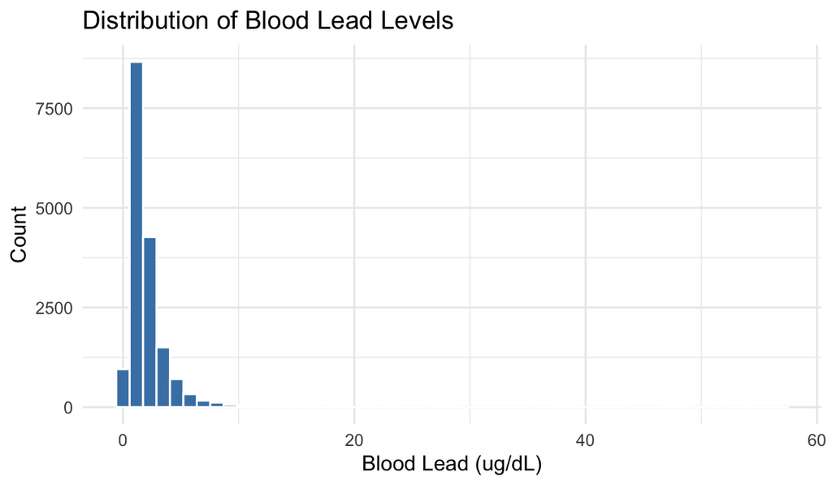

```r
ggplot(NHData.train, aes(x = LBXBPB)) +
  geom_histogram(bins = 50, fill = "steelblue", color = "white") +
  labs(x = "Blood Lead (ug/dL)", y = "Count",
       title = "Distribution of Blood Lead Levels") +
  theme_minimal()
```

## Challenges of Exposome Research

1. **Multiple testing**: hundreds of tests inflate false positives
2. **Correlation among exposures**: exposures are not independent
3. **Confounding**: demographic and socioeconomic factors affect both exposure and outcome
4. **Measurement error**: biomarkers are imperfect proxies of true exposure
5. **Reverse causation**: disease may affect exposure levels
6. **Temporal variability**: single time-point measurement

## The Multiple Testing Problem

- Testing 160 exposures simultaneously
- At \(\alpha = 0.05\), we expect ~8 false positives by chance
- Solutions:
  - **Bonferroni correction**: \(\alpha / m\) (conservative)
  - **Benjamini-Hochberg FDR**: controls false discovery rate (less conservative)
- More detail in Module 3

## Correlation Among Exposures

- Environmental exposures are often correlated
  - Smokers have higher cadmium AND lead
  - Dietary nutrients co-occur in food patterns
  - Pollutants share environmental sources
- Correlated exposures complicate interpretation
- Cannot isolate the “causal” exposure from correlated panel

## Confounding

- A **confounder** is a variable that influences both the exposure and the outcome
- Example: **age** affects both lead levels (older cohorts had more lead exposure) and BMI
- Must adjust for confounders in regression models
- Common confounders: age, sex, race/ethnicity, socioeconomic status

## Key References

1. **Wild CP.** Complementing the genome with an “exposome.” *Cancer Epidemiol Biomarkers Prev.* 2005.
2. **Patel CJ, Bhattacharya J, Butte AJ.** An Environment-Wide Association Study (EWAS) on Type 2 Diabetes Mellitus. *PLoS ONE.* 2010.
3. **Patel CJ, et al.** A database of human exposomes and phenomes from the US NHANES. *Scientific Data.* 2016.
4. **Chung MK, et al.** The exposome and exposome-wide association studies. *Exposome.* 2024.

## What’s Next?

**Module 2: R and Tidyverse Foundations**

- The pipe operator and dplyr verbs
- Data visualization with ggplot2
- Linear regression with broom
- Building pipelines for many regressions

## Summary

- The **exposome** represents the totality of environmental exposures
- **ExWAS** systematically scans exposures for associations with health outcomes
- **NHANES** provides a rich, publicly available dataset for ExWAS
- Key challenges: multiple testing, confounding, correlation, measurement error
- This course will teach you to conduct, interpret, and extend ExWAS analyses